# Ark spectra

Justin Pomeranz

12/27/2021

## Overview

Preliminary analyses for Arkansas Size Spectra project

Not shown: stitching all of the CSVs together, adding length-weight regression coefficients and estimating dry weight (dw) measurements

```r
head(dw)
```

```
##           dw site rep
## 1 0.09163291  AR1  s1
## 2 0.05760572  AR1  s1
## 3 0.04455635  AR1  s1
## 4 0.05212328  AR1  s1
## 5 0.23043993  AR1  s1
## 6 0.08508589  AR1  s3
```

## “Bin” the data based on body size

### Size spectra

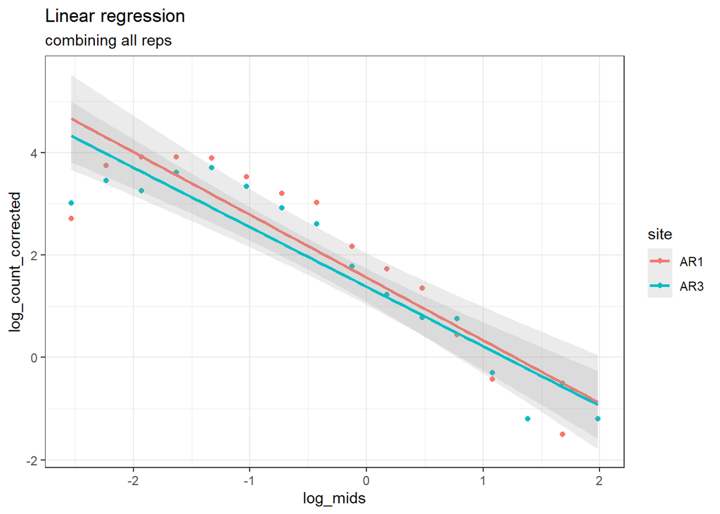

This looks really good! I’m surprised that the slopes are so similar, but this is pretty much exactly what we would expect size spectra relationships to look like.

## Stats for above plot

We can look at the values of the size spectra by running a simple linear regression

```r
summary(lm_mod)
```

```
##
## Call:
## lm(formula = log_count_corrected ~ log_mids_center * site, data = bin)
##
## Residuals:
##      Min       1Q   Median       3Q      Max
## -1.95599 -0.40095  0.06996  0.56999  0.94174
##
## Coefficients:
##                         Estimate Std. Error t value Pr(>|t|)
## (Intercept)              2.08193    0.19014  10.949 1.96e-11 ***
## log_mids_center         -1.22595    0.13939  -8.795 2.07e-09 ***
## siteAR3                 -0.20482    0.26536  -0.772    0.447
## log_mids_center:siteAR3  0.06223    0.19239   0.323    0.749
## ---
## Signif. codes:  0 '***' 0.001 '**' 0.01 '*' 0.05 '.' 0.1 ' ' 1
##
## Residual standard error: 0.7361 on 27 degrees of freedom
## Multiple R-squared:  0.8524, Adjusted R-squared:  0.836
## F-statistic: 51.97 on 3 and 27 DF,  p-value: 2.399e-11
```

This is showing us that there is no difference between the two sites. As I said, this is surprising to me, but this is still a pretty incredible result; the aquatic communities here have similar biomass structures, despite profound (?) differences in community composition and chemical attributes.

## Other analyses

Because we are looking at a “small” range of body sizes (i.e., only macroinvertebrates), it is recommended to fit quadratic relationships and compare the explanatory power:

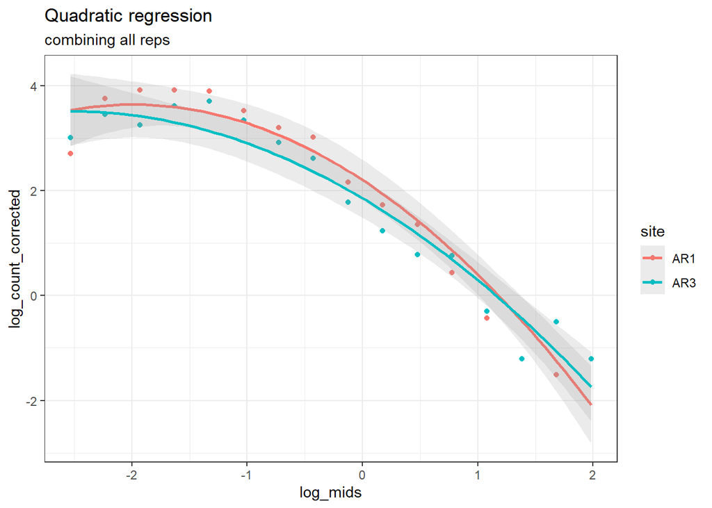

```r
summary(quad_mod)
```

```
##
## Call:
## lm(formula = log_count_corrected ~ log_mids_center * site + I(log_mids_center^2),
##     data = bin)
##
## Residuals:
##     Min      1Q  Median      3Q     Max
## -0.9934 -0.3524  0.0318  0.3168  0.7014
##
## Coefficients:
##                         Estimate Std. Error t value Pr(>|t|)
## (Intercept)              2.65382    0.15127  17.543 6.26e-16 ***
## log_mids_center         -1.14889    0.08985 -12.787 1.01e-12 ***
## siteAR3                 -0.18866    0.16949  -1.113    0.276
## I(log_mids_center^2)    -0.30902    0.04874  -6.340 1.03e-06 ***
## log_mids_center:siteAR3  0.07819    0.12290   0.636    0.530
## ---
## Signif. codes:  0 '***' 0.001 '**' 0.01 '*' 0.05 '.' 0.1 ' ' 1
##
## Residual standard error: 0.4701 on 26 degrees of freedom
## Multiple R-squared:  0.942,  Adjusted R-squared:  0.9331
## F-statistic: 105.6 on 4 and 26 DF,  p-value: 1.107e-15
```

There is still no difference between the two sites, but it does look like the quadratic term explains a lot of the variation and will likely be important to include.

## Including variation between reps

The results shown above are combining all of the reps (surbers) together, essentially giving us one estimate of the community composition per site.

Interestingly, when I bin the data separately within each rep and use these to estimate the size spectra we get slightly different results for both the linear and the quadratic analysis:

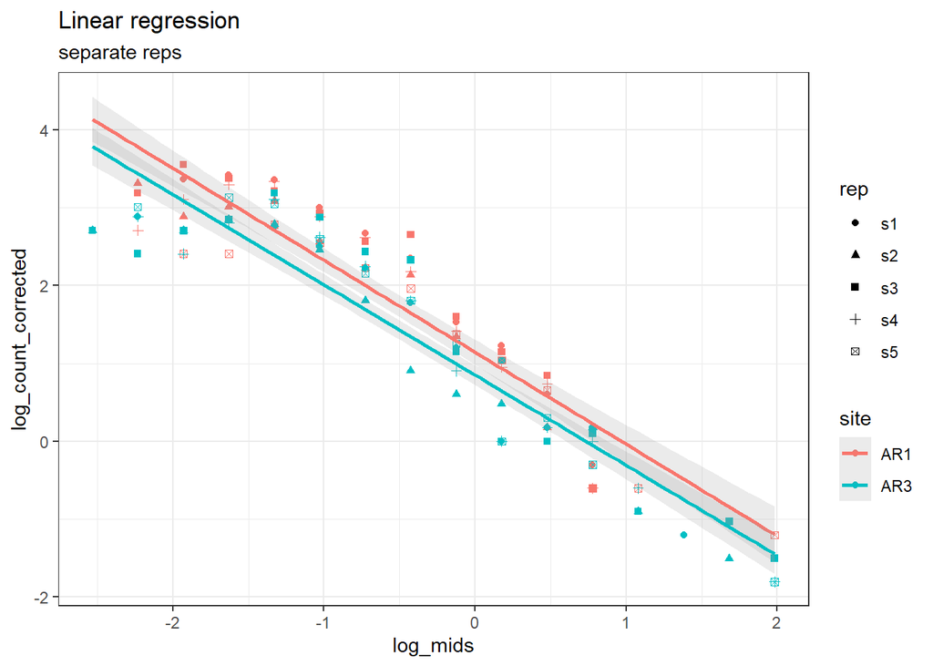

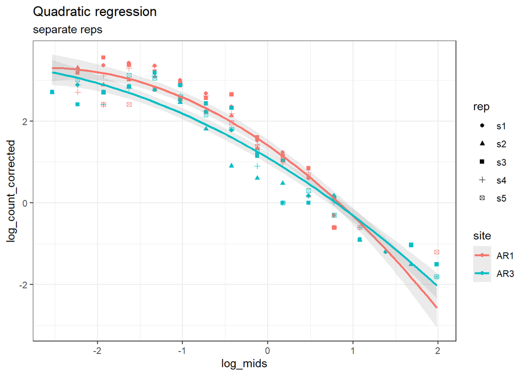

```r
summary(rep.lm)
```

```
##
## Call:
## lm(formula = log_count_corrected ~ log_mids_center * site, data = bin)
##
## Residuals:
##      Min       1Q   Median       3Q      Max
## -1.25801 -0.41912  0.00958  0.41275  1.42958
##
## Coefficients:
##                          Estimate Std. Error t value Pr(>|t|)
## (Intercept)              1.922896   0.074533  25.799  < 2e-16 ***
## log_mids_center         -1.158261   0.070149 -16.512  < 2e-16 ***
## siteAR3                 -0.514305   0.103008  -4.993 2.04e-06 ***
## log_mids_center:siteAR3 -0.002609   0.090041  -0.029    0.977
## ---
## Signif. codes:  0 '***' 0.001 '**' 0.01 '*' 0.05 '.' 0.1 ' ' 1
##
## Residual standard error: 0.571 on 120 degrees of freedom
## Multiple R-squared:  0.8579, Adjusted R-squared:  0.8544
## F-statistic: 241.6 on 3 and 120 DF,  p-value: < 2.2e-16
```

```r
summary(rep.quad)
```

```
##
## Call:
## lm(formula = log_count_corrected ~ log_mids_center * site + I(log_mids_center^2),
##     data = bin)
##
## Residuals:
##      Min       1Q   Median       3Q      Max
## -1.12785 -0.30888  0.00459  0.40534  1.22602
##
## Coefficients:
##                         Estimate Std. Error t value Pr(>|t|)
## (Intercept)              2.17045    0.07126  30.459  < 2e-16 ***
## log_mids_center         -1.09679    0.05938 -18.470  < 2e-16 ***
## siteAR3                 -0.41795    0.08732  -4.786 4.93e-06 ***
## I(log_mids_center^2)    -0.22346    0.03099  -7.210 5.60e-11 ***
## log_mids_center:siteAR3  0.03135    0.07558   0.415    0.679
## ---
## Signif. codes:  0 '***' 0.001 '**' 0.01 '*' 0.05 '.' 0.1 ' ' 1
##
## Residual standard error: 0.4784 on 119 degrees of freedom
## Multiple R-squared:  0.9011, Adjusted R-squared:  0.8978
## F-statistic: 271.2 on 4 and 119 DF,  p-value: < 2.2e-16
```

The slopes still do not seem to vary between the two sites, but in this case it looks like the intercepts do vary between the two sites. The intercept is commonly interpreted as “total community abundance”. In other words, there are more individual bugs at AR1 than AR3. I’ll leave it to Will to confirm this result, but this makes intuitive sense to me; lower overall abundance/biomass at the impacted site.

## So which analysis?

Great question, and the short answer is: I don’t know! There is actually a bit of an open question on whether or not size spectra are best estimated by combining all the data (first results above) or using different samples (surbers) to estimate the relationship.

## next samples?

This might be worth having a meeting to discuss.

### season?

One question I have beforehand is wich season were these samples from? Spring or summer? – One option would be to try other seasons from this same year to see if there are seasonal differences. My instinct is that Spring would have the greatest differences, but I could be wrong, especially if spring samples are pre-runoff.

### AR1 impacts?

Also, I believe Will said that AR1 might have also been impacted at the beginning of the study; are these samples after the restoration of LMDT occured? Are there samples of AR1 post-LMDT restoration but pre-CA gulch restoration? – Sampling in this “window” might reveal greater differences between the two sites

### longitudinal effects?

Impacts lower down at AR4 or 5? I don’t think this is likely, but the longitudinal effects may be more pronounced i.e., AR3 might be close enough to the unimpacted sites that individuals are drifting down and inflating the size spectra relationship

### Post restoration samples

Despite there not being profound differences pre-restoration, I still think that it would be a good idea to process some post-retoration sites from more recent years, 2018 or 19? – One thing we may need to figure out is if/how the subsampling routine affects estimates of size spectra. This might be possible using analytical techniques (i.e. me playing around with the data you already sent), or require a more robust pilot study (i.e., process the subsampled invertebrates, then complete a full-pick of the remaining sample which was not subsampled)

### ID to genus?

One thing I just thought of is that IDing everything to family may not be sensitive enough to detect differences. I think this is unlikely, and I could probably look at some of my old data to see if the taxonomic level makes a difference, but I mention it here for reference.